# **Time Series Analysis and Forecasting Report**

## Introduction

This report presents an analysis of a time series dataset representing monthly product sales from January 2015 to December 2024. The primary objective is to identify and fit the most appropriate time series models, with a specific focus on forecasting sales for the period from January to June 2025, while also providing prediction intervals to assess the reliability of these forecasts.

The analysis explores three different approaches: ARIMA, time-series regression, and dynamic linear models (DLM). Each method undergoes an iterative process involving model identification, estimation, and diagnostic checking to ensure accuracy. The results of these models are then compared to determine the most suitable method for reliable and effective forecasting of future sales.

## Model Identification and Fitting

### Data Preparation

The dataset comprises five columns, each representing a different dataset. For this analysis, dataset 3 (column 3) is selected. The data consists of 120 monthly observations.

```r
# Load and extract dataset
filename <- "projectdata.txt"
data <- read.table(filename, header = FALSE)
y <- data[, 3]
str(y)
```

```
##  num [1:120] 155.2 70.2 173.3 209 305.4 ...
```

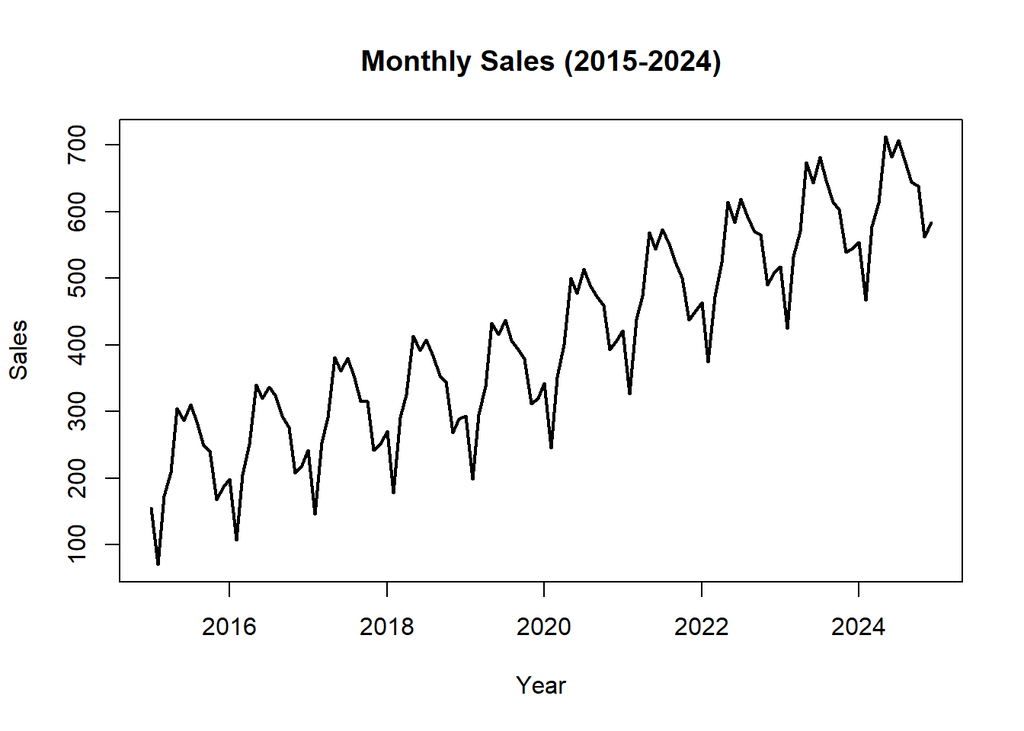

An additive model is appropriate because the magnitudes of seasonal fluctuations remain consistent over time. The data exhibits a general upward trend over the years, reflecting steady growth. Recurring seasonal patterns are evident, supporting the use of an additive model to capture these variations effectively.

First-order and seasonal differencing were applied to remove trends and seasonality, as demonstrated in below figure.

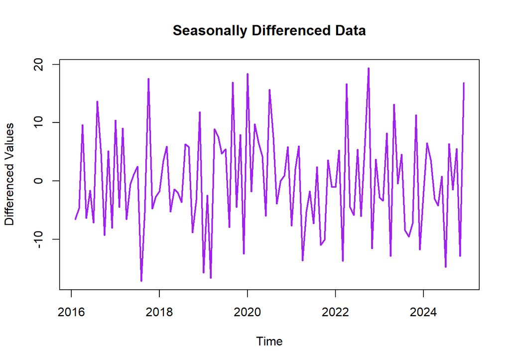

```r
# Apply differencing to remove trend and seasonality
diff_ts <- diff(diff(time_series, lag = 12)) # Seasonal differencing
plot(diff_ts, main = "Seasonally Differenced Data", ylab = "Differenced Values",
xlab = "Time", col = "purple", lw = 2)
```

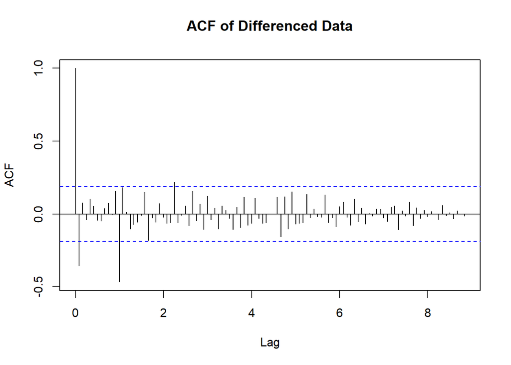

```r
# ACF and PACF plots
acf(diff_ts, main = "ACF of Differenced Data",lag.max = 1000)
```

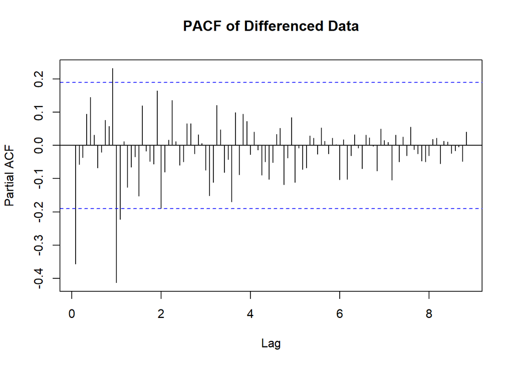

```r
pacf(diff_ts, main = "PACF of Differenced Data",lag.max = 1000)
```

```r
# Hypothesis: Mean of differenced series is equal to 0
t_test_result <- t.test(diff_ts, mu = 0)

# Print the result
print(t_test_result)
```

```
##
##  One Sample t-test
##
## data:  diff_ts
## t = -0.050672, df = 106, p-value = 0.9597
## alternative hypothesis: true mean is not equal to 0
## 95 percent confidence interval:
##  -1.676286  1.592735
## sample estimates:
##  mean of x
## -0.0417757
```

The t-test results indicate that seasonal differencing successfully removed trends and seasonality, resulting in a stationary series with a mean close to zero. The ACF plot shows significant spikes at lower lags before tapering off, suggesting the need for both autoregressive (AR) and moving average (MA) terms for further modeling, such as ARIMA.

### ARIMA Modeling

The ARIMA (AutoRegressive Integrated Moving Average) model is a powerful tool for modeling and forecasting time series data. It consists of three components, AutoRegressive (AR) which captures relationships between current and past values; Integrated (I), which uses differencing to achieve stationarity; and Moving Average (MA), which accounts for dependencies on past forecast errors. Together, these components allow ARIMA to effectively model trends, seasonality, and noise in time series data.

```r
(model_ar<-arima(time_series,order=c(1,1,0),seasonal=c(0,1,0)))
```

```
##
## Call:
## arima(x = time_series, order = c(1, 1, 0), seasonal = c(0, 1, 0))
##
## Coefficients:
##           ar1
##       -0.3685
## s.e.   0.0915
##
## sigma^2 estimated as 62.5:  log likelihood = -373.13,  aic = 750.26
```

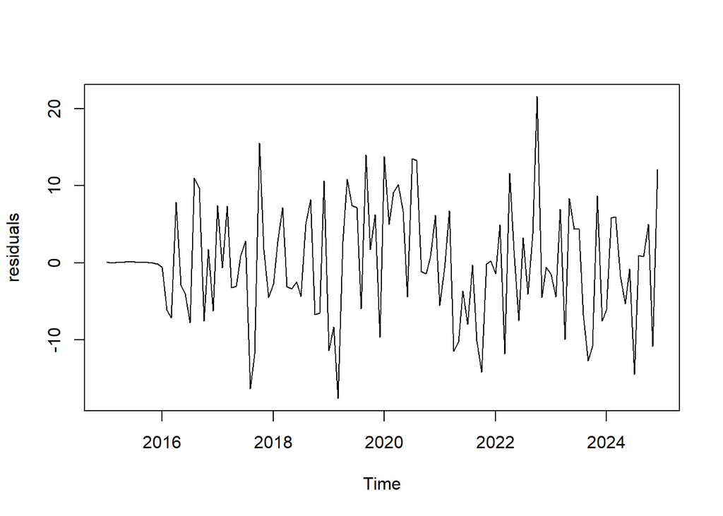

```r
##Extract residuals
resids=model_ar$residuals
##Plot residuals as a time series
plot(resids,ylab="residuals")
```

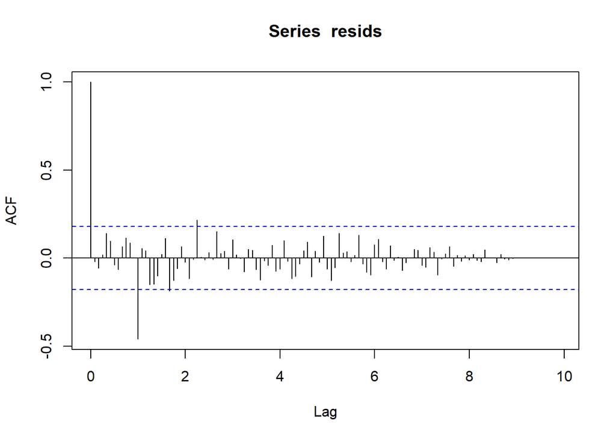

```r
##Plot acf and pacf
acf(resids,lag.max=500)
```

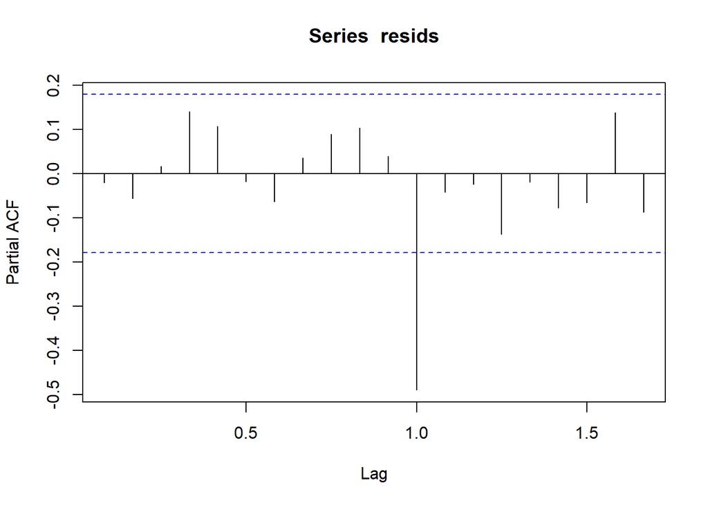

```r
pacf(resids)
```

```r
(model_sma<-arima(time_series,order=c(0,1,0),seasonal=c(0,1,1)))
```

```
##
## Call:
## arima(x = time_series, order = c(0, 1, 0), seasonal = c(0, 1, 1))
##
## Coefficients:
##          sma1
##       -0.7490
## s.e.   0.1059
##
## sigma^2 estimated as 44.19:  log likelihood = -359.43,  aic = 722.85
```

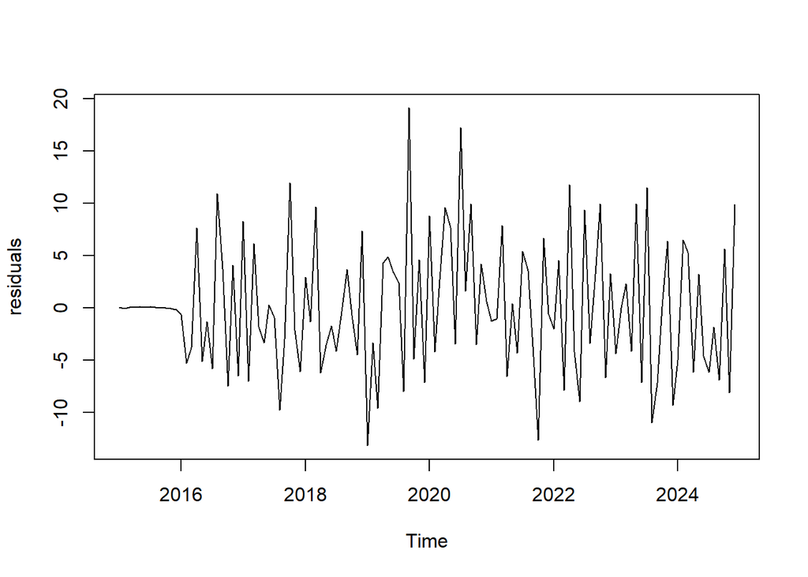

```r
##Extract residuals
resids=model_sma$residuals
##Plot residuals as a time series
plot(resids,ylab="residuals")
```

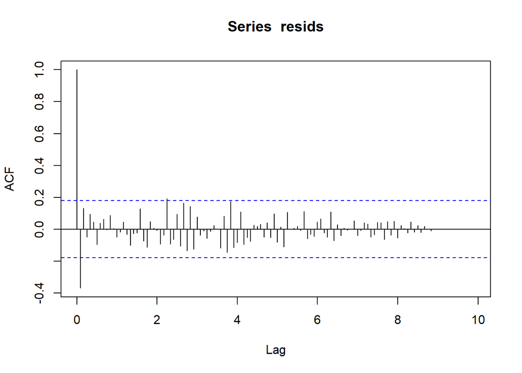

```r
##Plot acf and pacf
acf(resids,lag.max=500)
```

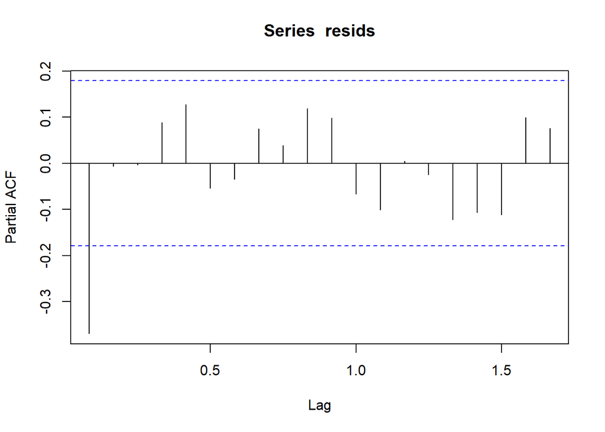

```r
pacf(resids)
```

```r
##Fitmodel
(model_arima=arima(time_series,order=c(1,1,0),seasonal=c(0,1,1)))
```

```
##
## Call:
## arima(x = time_series, order = c(1, 1, 0), seasonal = c(0, 1, 1))
##
## Coefficients:
##           ar1     sma1
##       -0.3903  -0.8528
## s.e.   0.0926   0.1645
##
## sigma^2 estimated as 36.03:  log likelihood = -351.21,  aic = 708.42
```

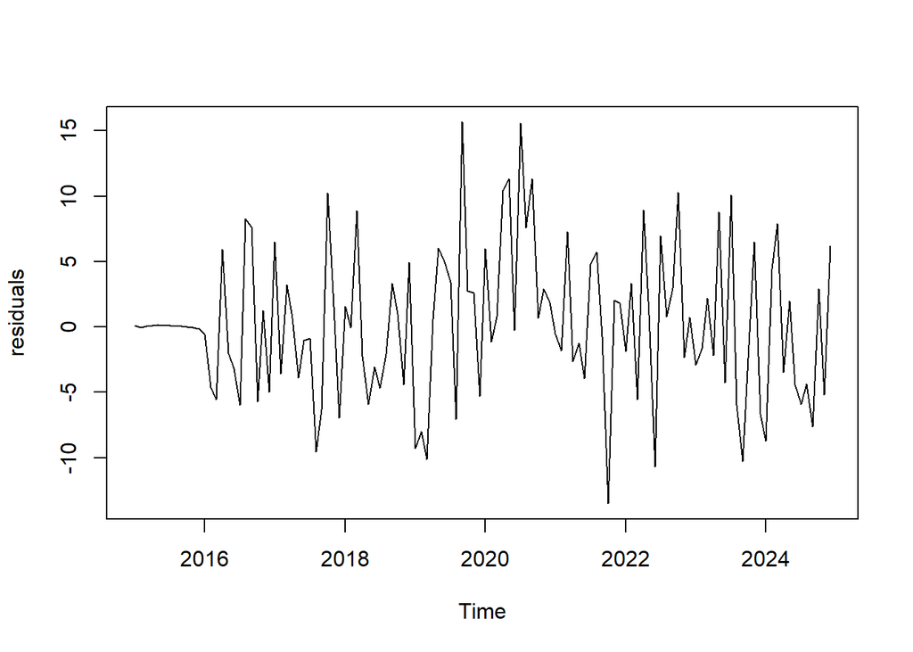

```r
##Extract residuals
resids=model_arima$residuals
##Plot residuals as a time series
plot(resids,ylab="residuals")
```

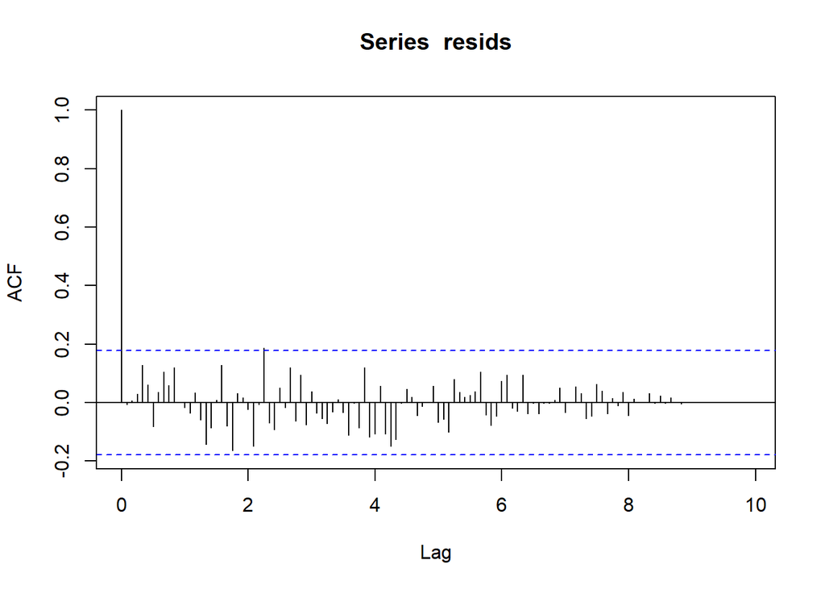

```r
##Plot acf and pacf
acf(resids,lag.max=500)
```

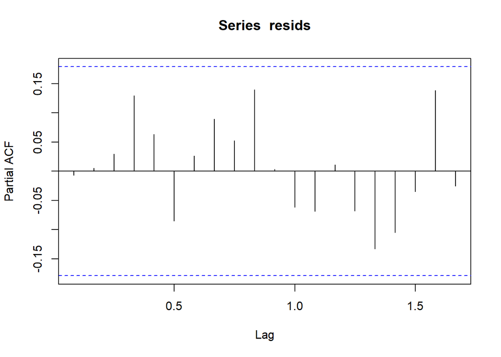

```r
pacf(resids)
```

```r
(model_2arima=arima(time_series,order=c(2,1,0),seasonal=c(0,1,1)))
```

```
##
## Call:
## arima(x = time_series, order = c(2, 1, 0), seasonal = c(0, 1, 1))
##
## Coefficients:
##           ar1      ar2     sma1
##       -0.3910  -0.0019  -0.8527
## s.e.   0.0993   0.0976   0.1646
##
## sigma^2 estimated as 36.04:  log likelihood = -351.21,  aic = 710.42
```

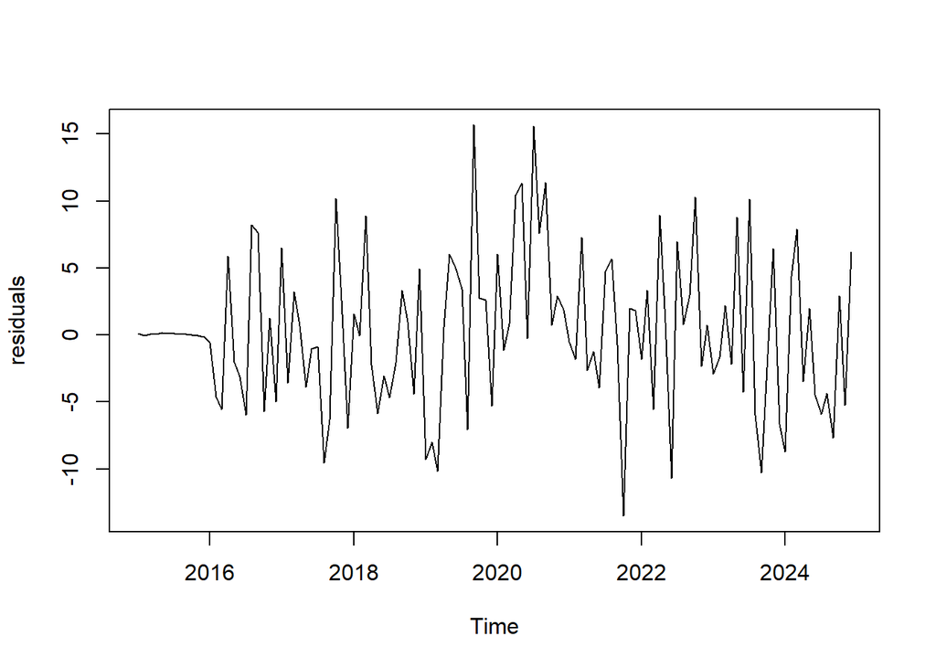

```r
##Extract residuals
resids=model_2arima$residuals
##Plot residuals as a time series
plot(resids,ylab="residuals")
```

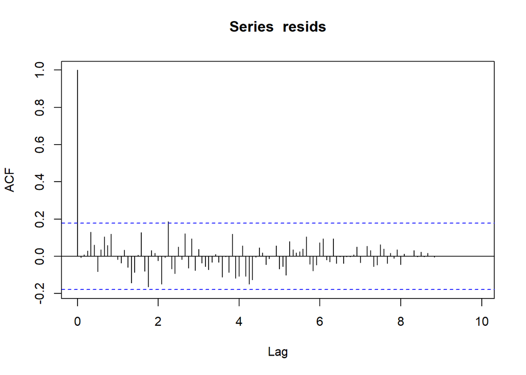

```r
##Plot acf and pacf
acf(resids,lag.max=500)
```

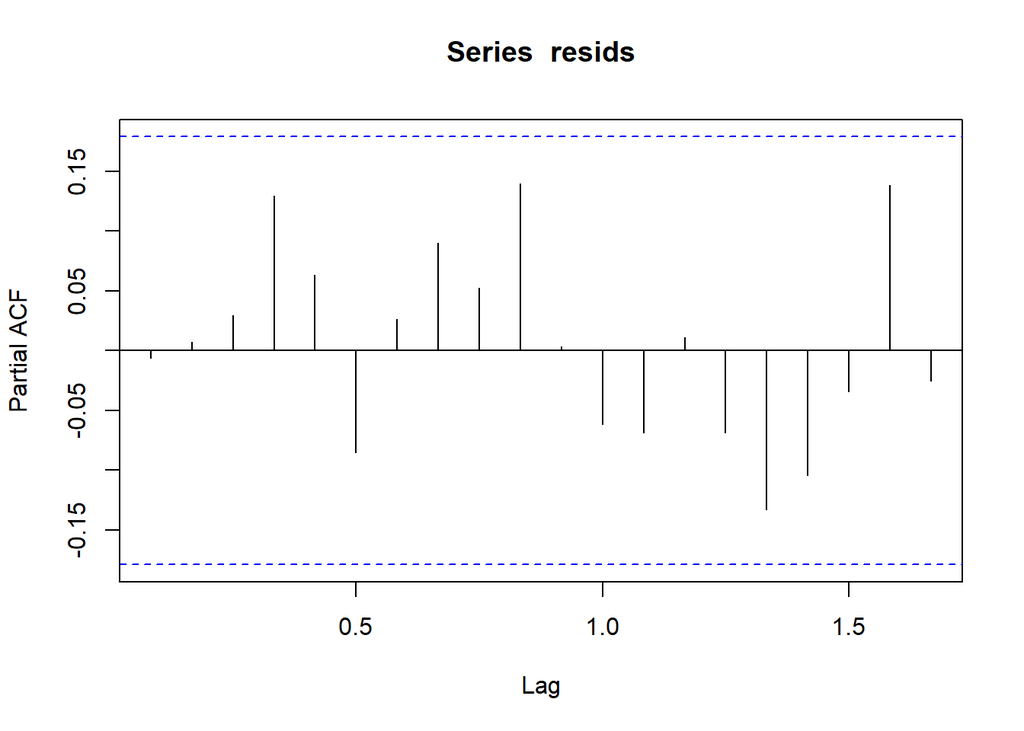

```r
pacf(resids)
```

Several ARIMA models were tested to identify the best fit. The table below summarizes the key features of each model, including the AR and MA coefficients, log-likelihood, AIC values, and a brief evaluation of the residuals:

| **Model** | **AR Terms** | **MA Terms** | **Seasonal MA Terms** | **Log-Likelihood** | **AIC** | **Residuals Behavior** |
| --- | --- | --- | --- | --- | --- | --- |
| **ARIMA(1,1,0) Seasonal(0,1,0)** | AR(1) = -0.3685 | None | None | -373.13 | 750.26 | Residuals exhibited some autocorrelation, suggesting room for improvement. |
| **ARIMA(0,1,0) Seasonal(0,1,1)** | None | None | SMA(1) = -0.7490 | -359.43 | 722.85 | Residuals improved, but some autocorrelation remained, showing a better fit than the first model. |
| **ARIMA(1,1,0) Seasonal(0,1,1)** | AR(1) = -0.3903 | None | SMA(1) = -0.8528 | -351.21 | 708.42 | Residuals showed significant improvement with fewer autocorrelations. This model provided the best fit. |
| **ARIMA(2,1,0) Seasonal(0,1,1)** | AR(1) = -0.3910, AR(2) = -0.0019 | None | SMA(1) = -0.8527 | -351.21 | 710.42 | Residuals slightly improved, but AIC was slightly higher, indicating no substantial gain in fit. |

Both ARIMA(1,1,0) with Seasonal(0,1,1) and ARIMA(2,1,0) with Seasonal(0,1,1) were found to provide a good fit based on residual analysis and ACF/PACF patterns.

To further evaluate the models, the **`sarima()`** function is used to perform additional diagnostics and assess the fit more thoroughly (see below).

```
## <><><><><><><><><><><><><><>
##
## Coefficients:
##      Estimate     SE t.value p.value
## ar1   -0.3903 0.0926 -4.2163   1e-04
## sma1  -0.8528 0.1645 -5.1841   0e+00
##
## sigma^2 estimated as 36.03232 on 105 degrees of freedom
##
## AIC = 6.620741  AICc = 6.62182  BIC = 6.69568
##
```

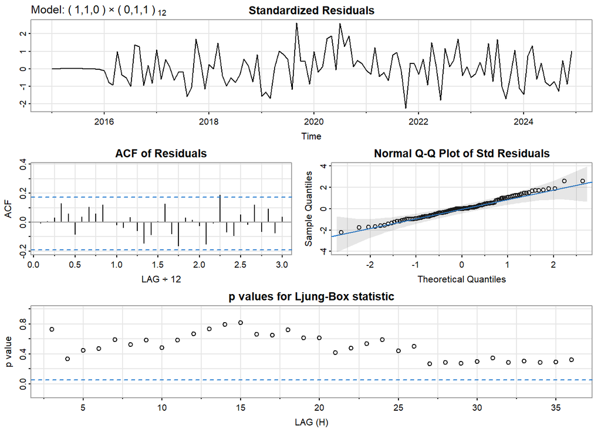

```r
model_sarima <- sarima(time_series, 1, 1, 0, 0, 1, 1, 12)
```

The model **ARIMA(1,1,0)(0,1,1)[12]** identified as the best fit, as it demonstrated high p-values in the Ljung-Box test, indicating no significant autocorrelation in the residuals, and all coefficient p-values were statistically significant (p < 0.05).

### Time-Series Regression Modeling

A time-series regression model is applied to the data, incorporating both a linear time trend and seasonal factors as predictors.

```r
# Residual analysis
time = c(1:120)
season = gl(12,1,120)
fit = lm(time_series~time+season)
```

The fitted values overlaid on the original time series to visually assess the model’s performance. The plot of monthly sales from 2015 to 2024 shows that the model captures both the trend and seasonal patterns effectively, with the fitted line closely following the observed data. This highlights the model’s accuracy in representing the underlying structure of the time series (shown below).

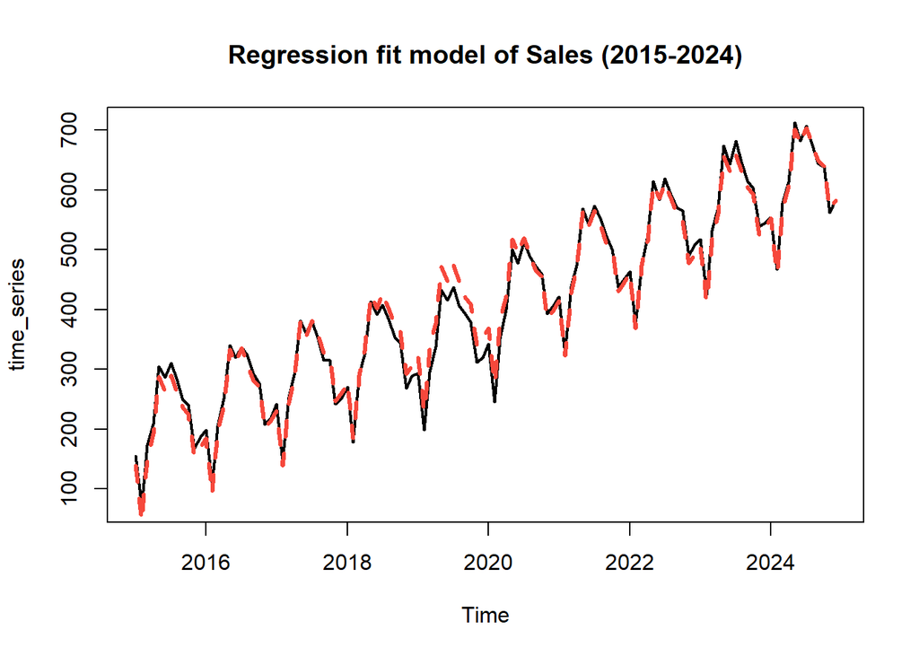

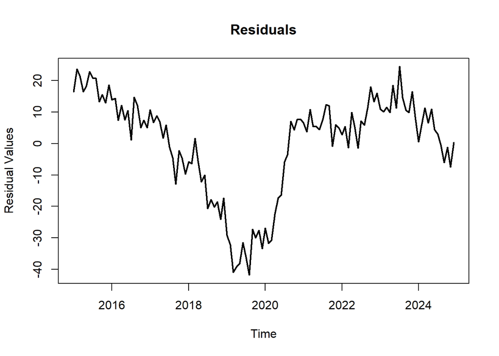

```r
resid <- ts(residuals(fit), start = c(2015, 1), frequency = 12)
plot(resid, main = "Residuals", ylab = "Residual Values", xlab = "Time", col = "black", lw = 2)
```

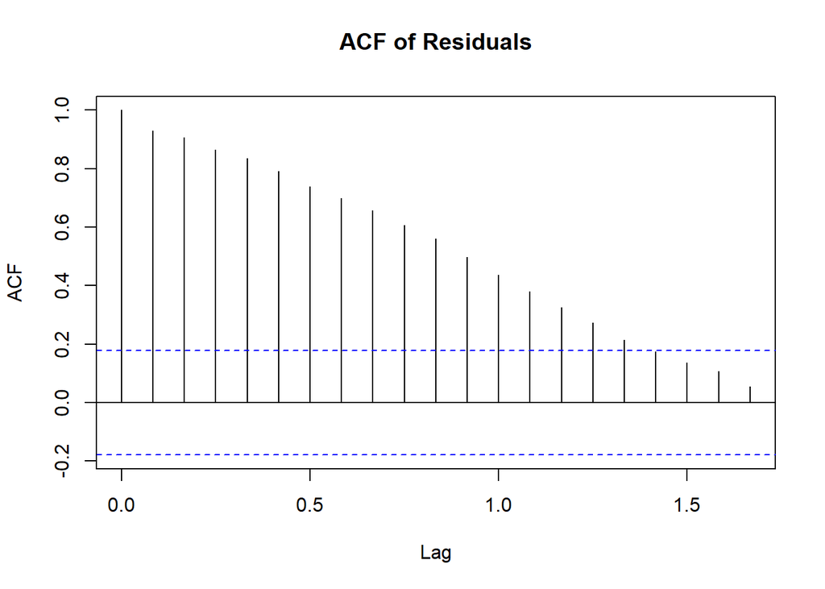

```r
acf(resid, main = "ACF of Residuals")
```

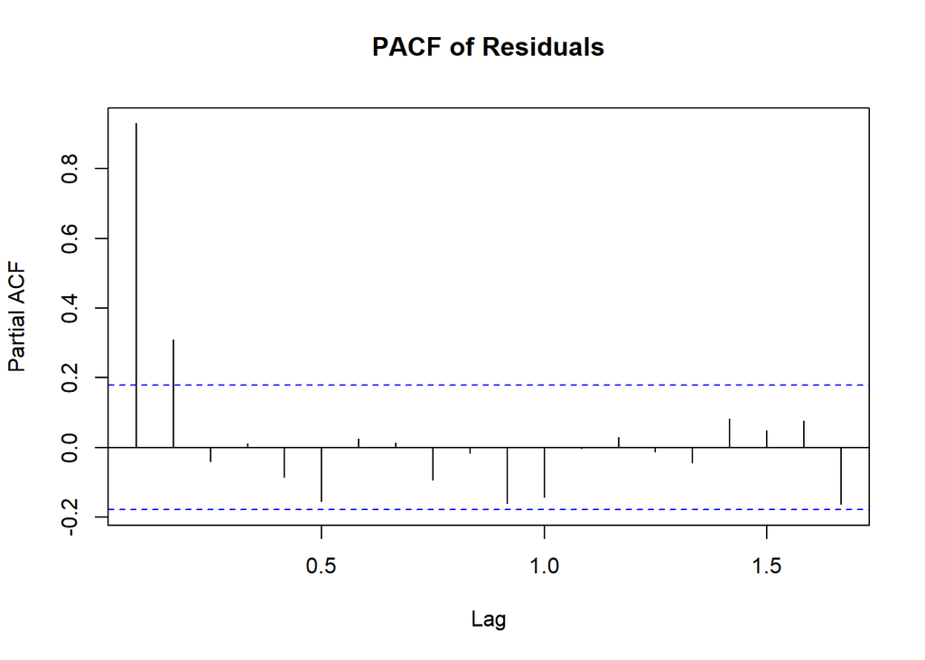

```r
pacf(resid, main = "PACF of Residuals")
```

```r
(mod1=arima(resid,order=c(1,0,1),include.mean=FALSE))
```

```
##
## Call:
## arima(x = resid, order = c(1, 0, 1), include.mean = FALSE)
##
## Coefficients:
##          ar1      ma1
##       0.9705  -0.3204
## s.e.  0.0201   0.0768
##
## sigma^2 estimated as 29.64:  log likelihood = -374.72,  aic = 755.44
```

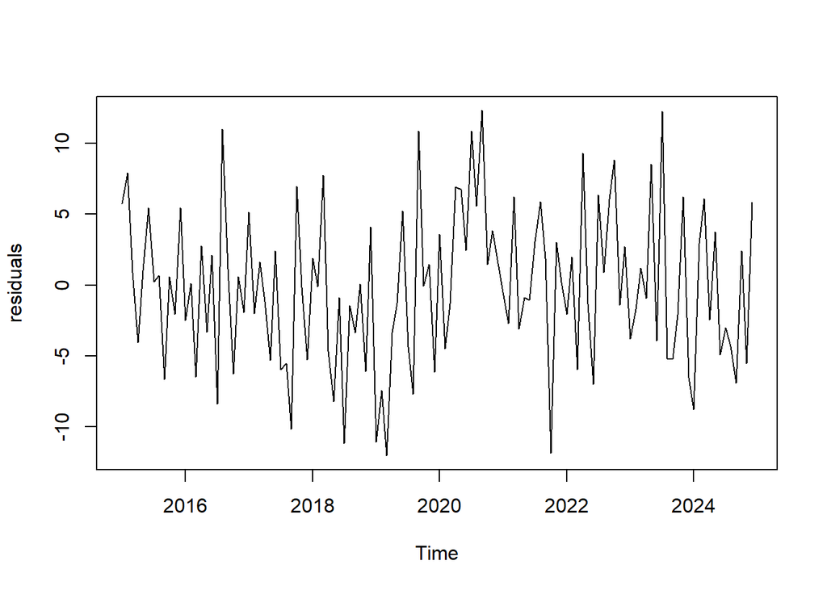

```r
plot(mod1$residuals,ylab="residuals")
```

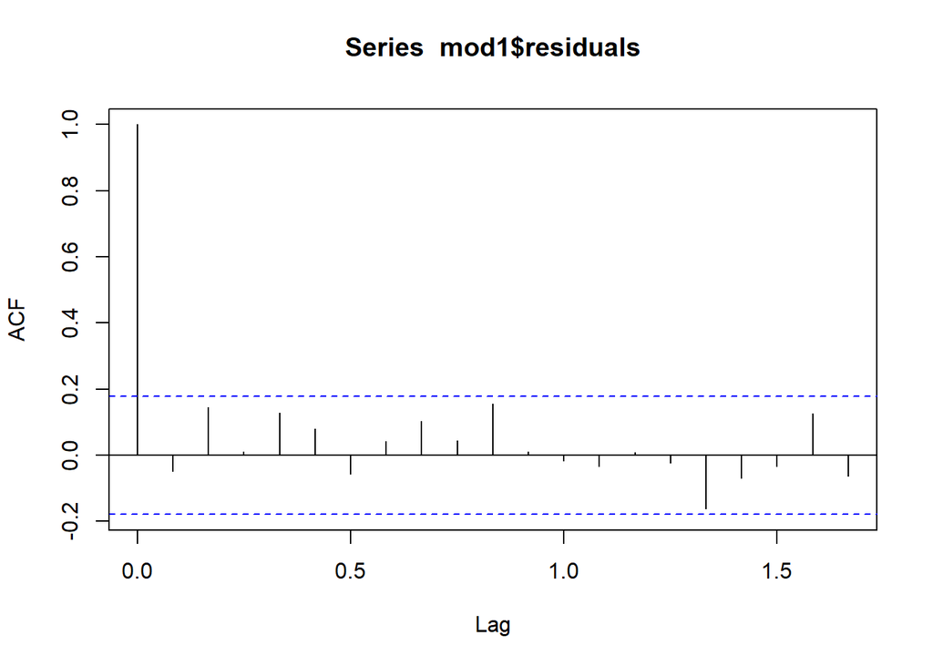

```r
acf(mod1$residuals)
```

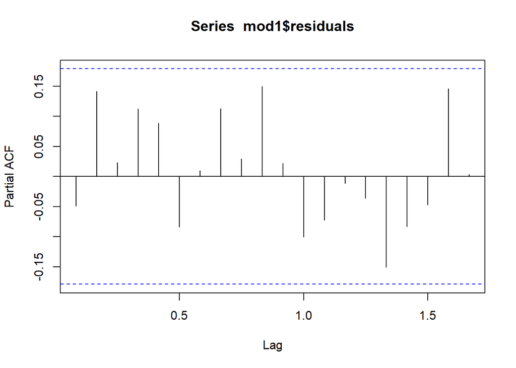

```r
pacf(mod1$residuals)
```

```r
(mod2a=arima(resid,order=c(2,0,1),include.mean=FALSE))
```

```
##
## Call:
## arima(x = resid, order = c(2, 0, 1), include.mean = FALSE)
##
## Coefficients:
##          ar1     ar2     ma1
##       0.5441  0.4084  0.0513
## s.e.  0.2293  0.2154  0.2506
##
## sigma^2 estimated as 28.87:  log likelihood = -373.19,  aic = 754.38
```

```r
m1<-mod2a$loglik
m<- mod1$loglik
(diff_pvalue<- m1-m)
```

```
## [1] 1.527378
```

```r
1-pchisq(diff_pvalue,df=1)
```

```
## [1] 0.2165063
```

[output not shown]

This model offers the optimal fit for the data, capturing dependencies while ensuring minimal error.

### Dynamic linear models

Dynamic Linear Models (DLMs) are state-space models that provide a flexible framework for modeling time series with complex structures. They accommodate time-varying trends, seasonality, and other features.

**Model Components**:

- Trend: Modeled as a second-order polynomial.
- Seasonality: Represented using Fourier terms or trigonometric functions.

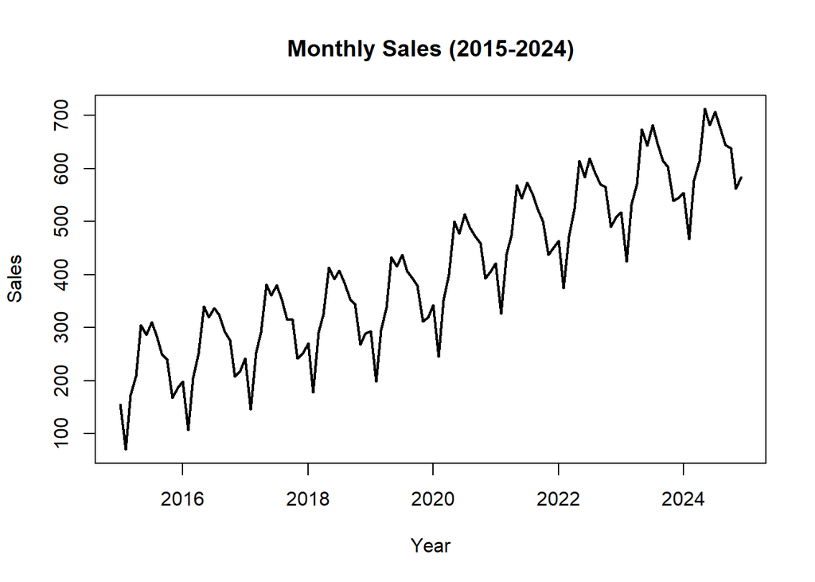

```r
plot(time_series, main = "Monthly Sales (2015-2024)", ylab = "Sales", xlab = "Year",lw=2)
```

**Model Fit**: A dynamic linear model (DLM) is constructed to model the time series data. The model includes a second-order polynomial component to capture the trend and a trigonometric component with seasonal frequency (s=12) to account for monthly seasonality.

```r
build_sales = function(params) {
  dlmModPoly(order=2,dV=exp(params[1]),dW=exp(params[2:3]))+
  dlmModTrig(s=12,dV=0,dW=exp(rep(params[4],11)))
}
sales_fit = dlmMLE(time_series, parm=c(0,0,0,0), build=build_sales)
sales_fit$convergence
```

```
## [1] 0
```

The model parameters are estimated using maximum likelihood estimation (MLE) through the `dlmMLE` function, which converges successfully, as indicated by a convergence value of 0.

```r
sales_mod = build_sales(sales_fit$par)
str(sales_mod)
```

```
## List of 10
##  $ m0 : num [1:13] 0 0 0 0 0 0 0 0 0 0 ...
##  $ C0 : num [1:13, 1:13] 1e+07 0e+00 0e+00 0e+00 0e+00 0e+00 0e+00 0e+00 0e+00 0e+00 ...
##  $ FF : num [1, 1:13] 1 0 1 0 1 0 1 0 1 0 ...
##  $ V  : num [1, 1] 11
##  $ GG : num [1:13, 1:13] 1 0 0 0 0 0 0 0 0 0 ...
##  $ W  : num [1:13, 1:13] 9.9 0 0 0 0 ...
##  $ JFF: NULL
##  $ JV : NULL
##  $ JGG: NULL
##  $ JW : NULL
##  - attr(*, "class")= chr "dlm"
```

This dynamic model effectively combines trend and seasonality components, providing a flexible framework for forecasting and understanding the time series behavior.

The smoothed results separate the observed sales data into:

- **Trend:** Capturing long-term movement.
- **Seasonality:** Representing recurring monthly patterns.

## Forecasting

### Forecast for January to June 2025

Forecasting sales using time series models involves analyzing historical sales data to predict future trends and patterns. For this analysis, SARIMA (Seasonal AutoRegressive Integrated Moving Average), Time-Series Regression, and Dynamic Linear Models (DLM) are utilized. Each method captures different aspects of the data, such as seasonality, trends, and potential structural changes. These techniques allow for robust predictions of future monthly sales, accompanied by 95% prediction intervals to account for uncertainty, providing valuable insights for planning and decision-making.

**ARIMA Forecast**

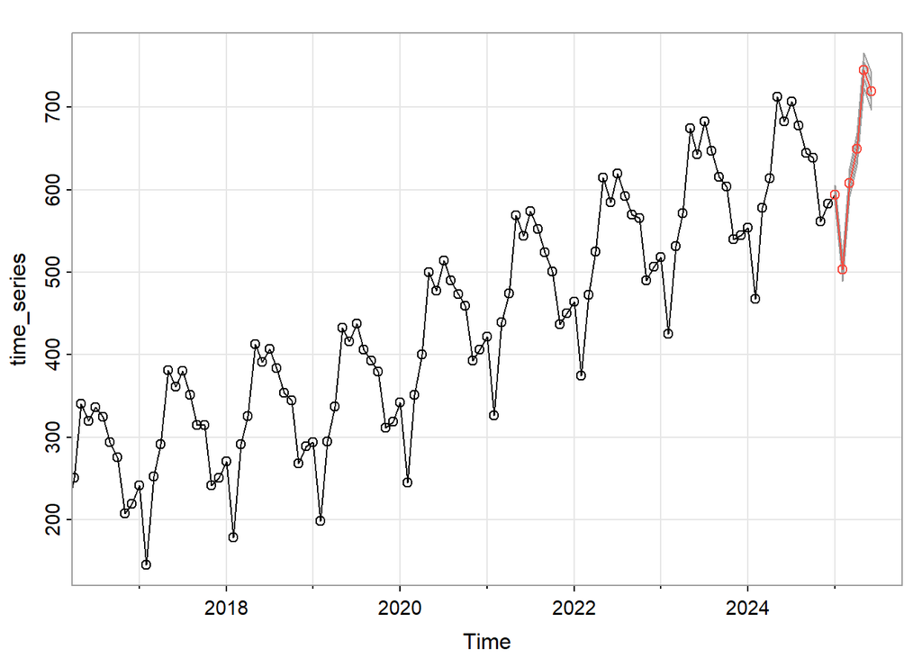

The forecasted values display a continued upward trend with seasonal fluctuations, and the 95% prediction intervals are calculated and plotted.

**Time-Series Regression Forecast**

Using a time-series regression approach, the forecast for monthly sales from January to June 2025 was generated by combining trend and seasonal components with residual adjustments. The model first extrapolates the trend for the forecasted months using the linear coefficients estimated from the regression. Seasonal effects, represented by the estimated seasonal coefficients, were added to the trend values to account for recurring patterns in the data. The residuals were then modeled using an ARIMA(2,0,0) process, and their predictions were incorporated to refine the forecast further.

The final forecasted values combine these three components—trend, seasonality, and residual adjustments—providing a more accurate prediction of future sales. Additionally, 95% prediction intervals were calculated to reflect the associated uncertainty, with upper and lower bounds generated using the forecast error.

```r
ar1 = arima(fit$resid,order=c(2,0,0))
ar1F = predict(ar1,n.ahead=6)
ar1F$pred = ts(ar1F$pred,start=c(2025,1),frequency=12)
```

```r
#This predicts the trend for the 6 next months
predictedTrend = fit$coef[1] + fit$coef[2]*(121:126)

#This predicts the seasonal effects within the same time  add more details about the magic
#numbers here
Seffects = c(0,fit$coef[3:7])

#and adds both components for a combined trend+seasonality forecast
predTS = predictedTrend + Seffects
```

```r
ar1FT = ar1F$pred + predTS
ar1F$se = ts(ar1F$se,start=c(2025,1),frequency=12)
ar1FTU = ar1FT + 2*ar1F$se
ar1FTL = ar1FT - 2*ar1F$se
```

The plot illustrates the historical time series along with the forecasted values, prediction intervals, and expected trajectory for the forecasted period. The forecasted sales, shown as a dashed red line, align closely with the observed trend and seasonality. The blue dashed lines represent the upper and lower 95% prediction intervals, capturing the range within which the actual values are likely to fall. This visualization shown below confirms that the model expects the upward trend to continue while retaining the seasonal fluctuations observed in historical data.

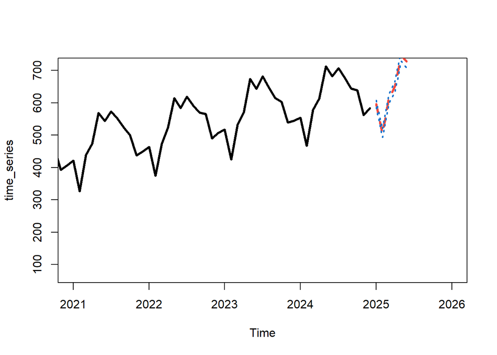

#### Dynamic Linear Model Forecast

A Dynamic Linear Model (DLM) was used to forecast sales for the next six months, providing point estimates and 95% prediction intervals. The forecasted values reflect the observed trend and seasonality, with prediction intervals offering bounds for potential variability.

```r
## Generate forecasts
sales_filt = dlmFilter(time_series, sales_mod)
sales_preds = dlmForecast(sales_filt, nAhead=6)
## Extract point forecasts and prediction interval limits
preds = sales_preds$f[,1]
lower = preds- 1.96 * sqrt(unlist(sales_preds$Q))
upper = preds + 1.96 * sqrt(unlist(sales_preds$Q))
```

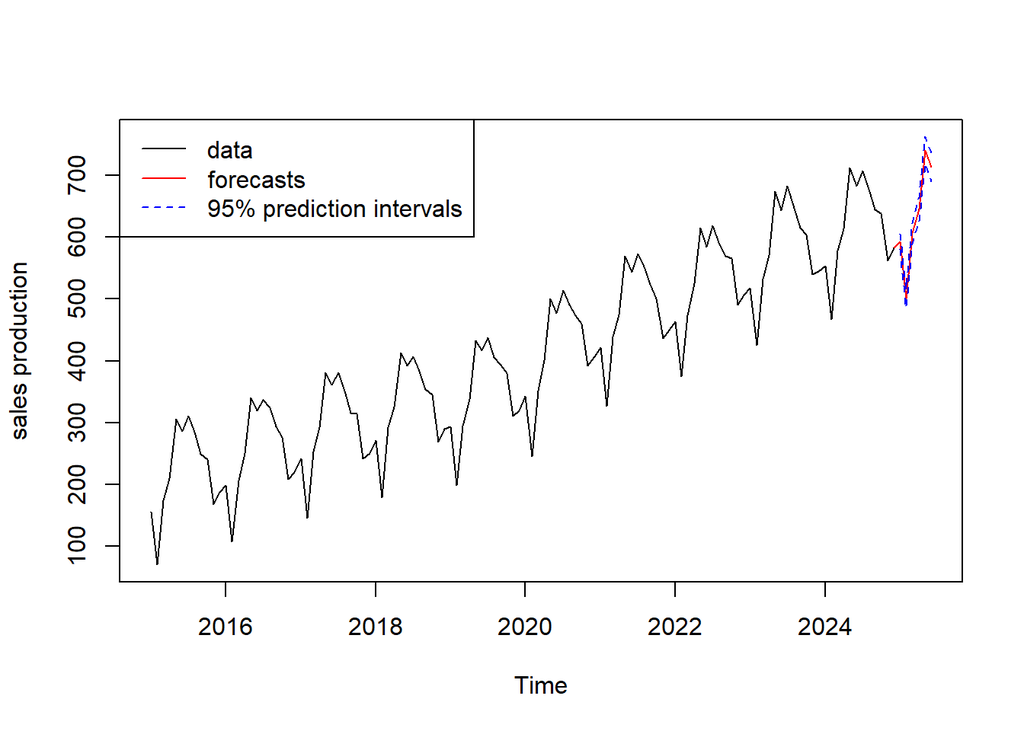

### Reliability of Forcasting

To evaluate the reliability of the forecasting methods, each model was trained on data from 2015 to 2023 (the first nine years), and forecasts were made for the subsequent twelve months (2024). The forecasts from the ARIMA, Time-Series Regression, and Dynamic Linear Model (DLM) were then compared to the actual observed values.

**Forcasting for the last 12 months Using Regression models**

A linear model is first fitted to the sales data from January 2015 to December 2023 to account for trend and seasonality. The residuals from this model are then used to fit an ARIMA(2,0,0) model. The forecast for January to December 2024 is obtained by combining the trend, seasonal effects, and ARIMA predictions, along with 95% prediction intervals.

The graph below shows the actual sales data (black line), forecasted values (red line), and the 95% prediction intervals (blue dashed lines).

```r
# Use only the first 9 years (Jan 2015 - Dec 2023) for fitting the model
time = c(1:108)
season = factor(rep(1:12, 9))

# Fit a linear model to the time series (trend + seasonality)
fit1 = lm(time_series[1:108] ~ time + season)

# Fit an ARIMA model to the residuals of the linear model
ar11 = arima(fit1$resid, order=c(2,0,0))
ar11F = predict(ar11, n.ahead=12)
ar11F$pred = ts(ar11F$pred, start=c(2024, 1), frequency=12)

predictedTrend1 = fit1$coef[1] + fit1$coef[2]*(109:120)
Seffects1 = fit1$coef[3:14]  # The seasonal coefficients (12 months)
predTS1 = predictedTrend1 + Seffects1

# Combine the forecast with the trend and seasonal components
ar11FT = ar11F$pred + predTS1
ar11F$se = ts(ar11F$se, start=c(2024, 1), frequency=12)

ar11FTU = ar11FT + 2*ar11F$se  # Upper bound
ar11FTL = ar11FT - 2*ar11F$se  # Lower bound
```

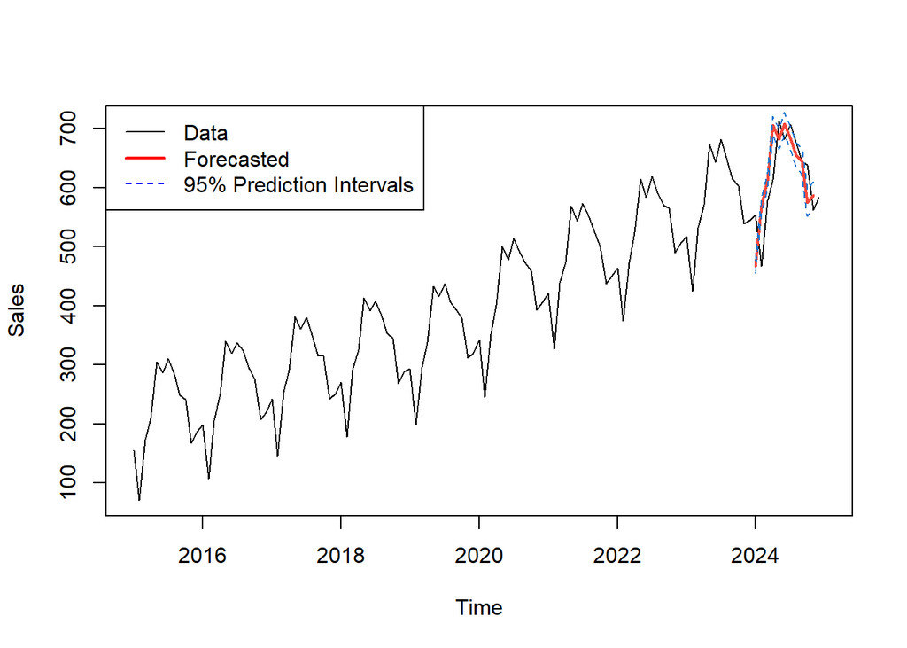

**Forcasting for the last 12 months Using DLM models**

[figure not shown]

```r
# Plot the original data, forecasted values, and prediction intervals
plot(sales_f, col="red", ylab="Sales Production", type="n", xlim=c(2015, 2025))  # Set xlim to span 2015-2025
lines(time_series, col="black")  # Original data line (Jan 2015 to Dec 2023)
lines(preds_f, col="red")  # Forecast line (Jan 2024 to Dec 2025)
lines(lower, lty=2, col="blue")  # Lower bound of prediction intervals
lines(upper, lty=2, col="blue")  # Upper bound of prediction intervals

# Add a legend to the plot
legend("topleft", c("Data", "Forecasts"),
       col=c("black", "red"), lty=c(1, 1), lwd=c(3, 3))
```

## Model Comparison

[output not shown]

ARIMA is preferred for its ability to produce accurate forecasts with moderate complexity. It effectively captures the underlying patterns in time series data, making it suitable for generating reliable predictions in many cases.

Regression models, on the other hand, offer simplicity and ease of interpretation. While they provide useful insights into the relationships between variables, they tend to lack long-term reliability when dealing with more complex time series data. This limits their effectiveness for extended forecasting periods.

Dynamic Linear Models (DLM) offer greater flexibility and comparable accuracy to ARIMA but come at a higher computational cost. They can adapt to changing trends and incorporate various components, making them versatile for different forecasting scenarios, though they require more resources to implement effectively.

## Conclusions

Sales data show an upward trend accompanied by consistent seasonality. Both ARIMA and DLM models prove reliable for forecasting, with ARIMA offering better accuracy and being more suitable for operational use. Time-series regression, while useful for explanatory analysis, is less effective for long-term predictions due to its simplicity and limited ability to capture complex patterns.

**Recommendation**: Given its accuracy and computational efficiency, ARIMA is recommended for operational forecasting and planning.